# Source Code Bab 6: Multivariate Regression

[figure not shown]

Informasi File

- Judul: **Hampiran Data dengan Regresi**
- Creator file: **Dr. Putu Harry Gunawan (Telkom University)**
- Bahasa Pemrograman: **Python**
- Membeli buku cetak: https://bit.ly/Teknik-Regresi-Data-Scientist

**Disclaimer:**

**Hak cipta ©2021** oleh Dr. Putu Harry Gunawan

1. Source code ini adalah pendamping dari buku Hampiran Data dengan Regresi.
2. Silakan dapat menyebarluaskan file ini, tanpa mengubah detail informasi file.

[figure not shown]

# Untuk dibaca

**Dengan Hormat**,

File ini adalah file Python sebagai latihan pendukung, sehingga beberapa kode yang ada dihapus dan dapat dilihat pada buku versi cetak. Dengan mencoba untuk mengetik kode Python sendiri, diharapkan anda dapat menguasai Python dengan cepat.

**Selamat Mencoba**

# Least Square Method

[figure not shown]

**Contoh**

Seorang peneliti menemukan bahwa jumlah panen jenis jamur Volvacea dan Auricula bergantung pada beberapa faktor eksternal yaitu suhu, kelembaban dan curah hujan seperti tabel di bawah ini,

[figure not shown]

Temukan fungsi estimasi jumlah panen jamur Volvacea dan Auricula menggunakan regresi linier multivariat menggunakan predictor Tempeature dan Moisture.

**solusi**

## Langkah 1. Membuat file atau membuka file dari url.

Pada langkah ini akan diberina contoh bagaimana membuat file atau membuka file dari url.

Pertama, kita pasang terlebihdahulu beberapa library yang akan digunakan dalam membangun model regresi.

```python
import numpy as np   #library management array dan numerik
import pandas as pd  #library tabel
from mpl_toolkits.mplot3d import Axes3D #untuk plot 3D
import matplotlib.pyplot as plt #library untuk plot
import scipy  #library untuk scientific computing
from scipy import stats #import khusus library Statistics
```

```python
data_exercise= {
    'Temp': [20, 25, 10, 30, 50, 40, 15],
    'Moisture': [30,15,40,42,10, 20, 35],
    'Volvacea': [80, 65, 70, 77, 60, 75, 68],
    'Auricula': [120, 118, 122, 119, 125, 129, 115]
    }
Data = pd.DataFrame(data_exercise)

Data
```

|  | Temp | Moisture | Volvacea | Auricula |
| --- | --- | --- | --- | --- |
| 0 | 20 | 30 | 80 | 120 |
| 1 | 25 | 15 | 65 | 118 |
| 2 | 10 | 40 | 70 | 122 |
| 3 | 30 | 42 | 77 | 119 |
| 4 | 50 | 10 | 60 | 125 |
| 5 | 40 | 20 | 75 | 129 |
| 6 | 15 | 35 | 68 | 115 |

## Langkah 2. Menentukan variable predictors (X) dan responses (Y)

```python
X = np.asanyarray(Data[['Temp','Moisture']])
Y = np.asanyarray(Data[['Volvacea','Auricula']])
m = len(Y)
```

plot data

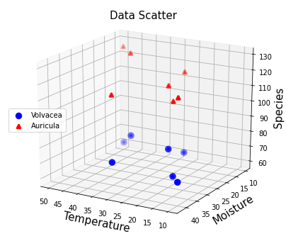

```python
fig = plt.figure(figsize=(7,6))
ax = fig.add_subplot(111, projection='3d')
ax.view_init(20, 120)
ax.scatter(X[:,0], X[:,1], Y[:,0],  color='blue',lw=5)
ax.scatter(X[:,0], X[:,1], Y[:,1], color='red', marker='^', linewidth=3)
plt.legend(('Volvacea','Auricula'), loc='center left')
ax.set_xlabel('Temperature',fontsize=15)
ax.set_ylabel('Moisture',fontsize=15)
ax.set_zlabel('Species', fontsize=15)
ax.set_title('Data Scatter', fontsize=15)
plt.show()
```

## Langkah 3. Membangun model regresi linier sederhana

Menentukan matriks $\textbf{A}$ dan $\mathbf{Y}$

Matriks $A$ \begin{equation*} \textbf{A}=\left[\begin{matrix} 1 & x_{11} & x_{12} & \cdots & x_{1n}\\ 1 & x_{21} & x_{22} & \cdots & x_{2n}\\ \vdots & \vdots & \vdots & \vdots & \vdots\\ 1 & x_{m1} & x_{m2} & \cdots & x_{mn} \end{matrix}\right]_{(m\times n+1)}, \end{equation*}

vektor $y$ \begin{equation*} \textbf{Y}=\left[\begin{matrix} y_{11} & \cdots & y_{1p}\\ y_{21} & \cdots & y_{2p}\\ \vdots & \vdots & \vdots \\ y_{m1} & \cdots & y_{mp} \end{matrix}\right]_{(m\times p)}. \end{equation*}

```python
A = np.insert(X, 0, np.ones(m), 1)
print(A)
```

```
[[ 1 20 30]
 [ 1 25 15]
 [ 1 10 40]
 [ 1 30 42]
 [ 1 50 10]
 [ 1 40 20]
 [ 1 15 35]]
```

Mencari koefisien $C$

Permasalahan Least Squared, \begin{equation*} \displaystyle \min_{\mathbf{C} \in \mathbb{R}^{(n+1) \times p}}|| \mathbf{Y} - \hat{\mathbf{Y}}||^2, \end{equation*} atau \begin{equation*} \displaystyle \min_{\mathbf{C} \in \mathbb{R}^{(n+1) \times p}}|| \mathbf{Y} - \mathbf{AC}||^2. \end{equation*} dengan $||\cdot||$ menotasikan Frobenius norm.

solusinya adalah \begin{equation*} \mathbf{C} = (\mathbf{A'A})^{-1} \mathbf{A'Y} \end{equation*}

```python
C = np.linalg.inv(np.transpose(A)@A)@np.transpose(A)@Y
print("Coefficients: ")
print(C)
```

```
Coefficients:
[[5.62388851e+01 1.14711682e+02]
 [1.11467091e-01 2.24143503e-01]
 [4.17443005e-01 1.26612639e-02]]
```

**Memvisualisaiskan data dan fungsi hampiran**

```python
def fVolvacea(x1,x2):
  return C[0][0] + C[1][0]*x1 + C[2][0]*x2

def fAuricula(x1,x2):
  return C[0][1] + C[1][1]*x1 + C[2][1]*x2
```

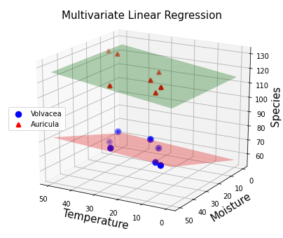

```python
from mpl_toolkits.mplot3d import Axes3D
import matplotlib.pyplot as plt

xp = np.linspace(0,50,100)
yp = np.linspace(0,50,100)

Xp,Yp = np.meshgrid(xp,yp)
Z1 = fVolvacea(Xp,Yp)
Z2 = fAuricula(Xp,Yp)


fig = plt.figure(figsize=(7,6))
ax = fig.add_subplot(111, projection='3d')
ax.view_init(20, 120)
ax.scatter(Data.Temp, Data.Moisture, Data.Volvacea,  color='blue',lw=5)
ax.scatter(Data.Temp, Data.Moisture, Data.Auricula, color='red', marker='^', linewidth=3)
ax.plot_surface(Xp, Yp, Z1, alpha=0.3, color='red', rstride=6, cstride=12)
ax.plot_surface(Xp, Yp, Z2, alpha=0.3, color='green', rstride=6, cstride=12)
plt.legend(('Volvacea','Auricula'), loc='center left')
ax.set_xlabel('Temperature',fontsize=15)
ax.set_ylabel('Moisture',fontsize=15)
ax.set_zlabel('Species', fontsize=15)
ax.set_title('Multivariate Linear Regression', fontsize=15)
plt.show()
```

## Langkah 4. Evaluasi model

Hypothesis testing and Tabel ANOVA untuk multivariate linear regression

[figure not shown]

```python
def ANOVATAB_MVLR(y,yhat,n,p,m):
  dfn = p*n
  dfd = p*(m-n-1)
  ybar = np.average(y)

  SSR = np.sum((yhat - ybar)@np.transpose(yhat - ybar))
  SSE = np.sum((y-yhat)@np.transpose(y-yhat))
  SST = np.sum((y-ybar)@np.transpose(y-ybar))
  MSR = SSR/dfn
  MSE = SSE/dfd

  Fs = MSR/MSE
  ks = 1-scipy.stats.f.cdf(Fs, dfn, dfd)
  data_table= {
    'SS': [SSR, SSE, SST],
    'df': [dfn, dfd,m-1] ,
    'MS': [MSR, MSE,'-'],
    'Fs': [Fs, '-','-'],
    'pval': [ks, '-','-']
  }

  return pd.DataFrame(data_table)
```

Menentukan data hampiran, matriks $\hat{\mathbf{Y}}$, yaitu

\begin{equation*} \hat{\mathbf{Y}} = \mathbf{AC} + \mathbf{E} \end{equation*}

dengan

\begin{equation*} \hat{\textbf{Y}}=\left[\begin{matrix} \hat{y}_{11} & \cdots & \hat{y}_{1p}\\ \hat{y}_{21} & \cdots & \hat{y}_{2p}\\ \vdots & \vdots & \vdots \\ \hat{y}_{m1} & \cdots & \hat{y}_{mp} \end{matrix}\right]_{(m\times p)} \end{equation*}

```python
Yhat = A@C
n=2
p=2
tabel = ANOVATAB_MVLR(Y,Yhat,n,p,m)
tabel
```

|  | SS | df | MS | Fs | pval |
| --- | --- | --- | --- | --- | --- |
| 0 | 6.230450e+04 | 4 | 15576.1 | 8.76858e+18 | 0 |
| 1 | 1.421085e-14 | 8 | 1.77636e-15 | - | - |
| 2 | 6.230450e+04 | 6 | - | - | - |

Dari tabel ANOVA di atas, didapatkan p-value < $\alpha=5%$, sehingga keputusan menolak $H_0$.

Kesimpulan: Dengan tingkat signifikansi $5%$, tidak cukup bukti bahwa $a_1= a_2= 0$ sehingga variabel Temp dan Moisture dapat digunakan untuk membentuk model regresi linier multivariat.

```python
MSE = tabel.MS[1]
print('MSE=',MSE)
```

```
MSE= 1.7763568394002505e-15
```

```python
SSE = tabel.SS[1]
SST = tabel.SS[2]
R2 = 1 - SSE/SST
print('R-squared =',R2*100,"%")
```

```
R-squared = 100.0 %
```

# Pendekatan Machine Learning

## Langkah 1. Menyiapkan dataset

```python
import pandas as pd

url = 'https://bit.ly/3dWextD'
df = pd.read_csv(url)

df
```

|  | id | diagnosis | radius_mean | texture_mean | perimeter_mean | area_mean | smoothness_mean | compactness_mean | concavity_mean | concave points_mean | symmetry_mean | fractal_dimension_mean | radius_se | texture_se | perimeter_se | area_se | smoothness_se | compactness_se | concavity_se | concave points_se | symmetry_se | fractal_dimension_se | radius_worst | texture_worst | perimeter_worst | area_worst | smoothness_worst | compactness_worst | concavity_worst | … |
| --- | --- | --- | --- | --- | --- | --- | --- | --- | --- | --- | --- | --- | --- | --- | --- | --- | --- | --- | --- | --- | --- | --- | --- | --- | --- | --- | --- | --- | --- | --- |
| 0 | 842302 | M | 17.99 | 10.38 | 122.80 | 1001.0 | 0.11840 | 0.27760 | 0.30010 | 0.14710 | 0.2419 | 0.07871 | 1.0950 | 0.9053 | 8.589 | 153.40 | 0.006399 | 0.04904 | 0.05373 | 0.01587 | 0.03003 | 0.006193 | 25.380 | 17.33 | 184.60 | 2019.0 | 0.16220 | 0.66560 | 0.7119 | … |
| 1 | 842517 | M | 20.57 | 17.77 | 132.90 | 1326.0 | 0.08474 | 0.07864 | 0.08690 | 0.07017 | 0.1812 | 0.05667 | 0.5435 | 0.7339 | 3.398 | 74.08 | 0.005225 | 0.01308 | 0.01860 | 0.01340 | 0.01389 | 0.003532 | 24.990 | 23.41 | 158.80 | 1956.0 | 0.12380 | 0.18660 | 0.2416 | … |
| 2 | 84300903 | M | 19.69 | 21.25 | 130.00 | 1203.0 | 0.10960 | 0.15990 | 0.19740 | 0.12790 | 0.2069 | 0.05999 | 0.7456 | 0.7869 | 4.585 | 94.03 | 0.006150 | 0.04006 | 0.03832 | 0.02058 | 0.02250 | 0.004571 | 23.570 | 25.53 | 152.50 | 1709.0 | 0.14440 | 0.42450 | 0.4504 | … |
| 3 | 84348301 | M | 11.42 | 20.38 | 77.58 | 386.1 | 0.14250 | 0.28390 | 0.24140 | 0.10520 | 0.2597 | 0.09744 | 0.4956 | 1.1560 | 3.445 | 27.23 | 0.009110 | 0.07458 | 0.05661 | 0.01867 | 0.05963 | 0.009208 | 14.910 | 26.50 | 98.87 | 567.7 | 0.20980 | 0.86630 | 0.6869 | … |
| 4 | 84358402 | M | 20.29 | 14.34 | 135.10 | 1297.0 | 0.10030 | 0.13280 | 0.19800 | 0.10430 | 0.1809 | 0.05883 | 0.7572 | 0.7813 | 5.438 | 94.44 | 0.011490 | 0.02461 | 0.05688 | 0.01885 | 0.01756 | 0.005115 | 22.540 | 16.67 | 152.20 | 1575.0 | 0.13740 | 0.20500 | 0.4000 | … |
| ... | ... | ... | ... | ... | ... | ... | ... | ... | ... | ... | ... | ... | ... | ... | ... | ... | ... | ... | ... | ... | ... | ... | ... | ... | ... | ... | ... | ... | ... | … |
| 564 | 926424 | M | 21.56 | 22.39 | 142.00 | 1479.0 | 0.11100 | 0.11590 | 0.24390 | 0.13890 | 0.1726 | 0.05623 | 1.1760 | 1.2560 | 7.673 | 158.70 | 0.010300 | 0.02891 | 0.05198 | 0.02454 | 0.01114 | 0.004239 | 25.450 | 26.40 | 166.10 | 2027.0 | 0.14100 | 0.21130 | 0.4107 | … |
| 565 | 926682 | M | 20.13 | 28.25 | 131.20 | 1261.0 | 0.09780 | 0.10340 | 0.14400 | 0.09791 | 0.1752 | 0.05533 | 0.7655 | 2.4630 | 5.203 | 99.04 | 0.005769 | 0.02423 | 0.03950 | 0.01678 | 0.01898 | 0.002498 | 23.690 | 38.25 | 155.00 | 1731.0 | 0.11660 | 0.19220 | 0.3215 | … |
| 566 | 926954 | M | 16.60 | 28.08 | 108.30 | 858.1 | 0.08455 | 0.10230 | 0.09251 | 0.05302 | 0.1590 | 0.05648 | 0.4564 | 1.0750 | 3.425 | 48.55 | 0.005903 | 0.03731 | 0.04730 | 0.01557 | 0.01318 | 0.003892 | 18.980 | 34.12 | 126.70 | 1124.0 | 0.11390 | 0.30940 | 0.3403 | … |
| 567 | 927241 | M | 20.60 | 29.33 | 140.10 | 1265.0 | 0.11780 | 0.27700 | 0.35140 | 0.15200 | 0.2397 | 0.07016 | 0.7260 | 1.5950 | 5.772 | 86.22 | 0.006522 | 0.06158 | 0.07117 | 0.01664 | 0.02324 | 0.006185 | 25.740 | 39.42 | 184.60 | 1821.0 | 0.16500 | 0.86810 | 0.9387 | … |
| 568 | 92751 | B | 7.76 | 24.54 | 47.92 | 181.0 | 0.05263 | 0.04362 | 0.00000 | 0.00000 | 0.1587 | 0.05884 | 0.3857 | 1.4280 | 2.548 | 19.15 | 0.007189 | 0.00466 | 0.00000 | 0.00000 | 0.02676 | 0.002783 | 9.456 | 30.37 | 59.16 | 268.6 | 0.08996 | 0.06444 | 0.0000 | … |

569 rows × 32 columns

Mengambil data hanya yang memeiliki diagnosis B = benign

```python
data = df.loc[df['diagnosis'] == 'B']
data
```

|  | id | diagnosis | radius_mean | texture_mean | perimeter_mean | area_mean | smoothness_mean | compactness_mean | concavity_mean | concave points_mean | symmetry_mean | fractal_dimension_mean | radius_se | texture_se | perimeter_se | area_se | smoothness_se | compactness_se | concavity_se | concave points_se | symmetry_se | fractal_dimension_se | radius_worst | texture_worst | perimeter_worst | area_worst | smoothness_worst | compactness_worst | concavity_worst | … |
| --- | --- | --- | --- | --- | --- | --- | --- | --- | --- | --- | --- | --- | --- | --- | --- | --- | --- | --- | --- | --- | --- | --- | --- | --- | --- | --- | --- | --- | --- | --- |
| 19 | 8510426 | B | 13.540 | 14.36 | 87.46 | 566.3 | 0.09779 | 0.08129 | 0.06664 | 0.047810 | 0.1885 | 0.05766 | 0.2699 | 0.7886 | 2.058 | 23.560 | 0.008462 | 0.014600 | 0.02387 | 0.013150 | 0.01980 | 0.002300 | 15.110 | 19.26 | 99.70 | 711.2 | 0.14400 | 0.17730 | 0.23900 | … |
| 20 | 8510653 | B | 13.080 | 15.71 | 85.63 | 520.0 | 0.10750 | 0.12700 | 0.04568 | 0.031100 | 0.1967 | 0.06811 | 0.1852 | 0.7477 | 1.383 | 14.670 | 0.004097 | 0.018980 | 0.01698 | 0.006490 | 0.01678 | 0.002425 | 14.500 | 20.49 | 96.09 | 630.5 | 0.13120 | 0.27760 | 0.18900 | … |
| 21 | 8510824 | B | 9.504 | 12.44 | 60.34 | 273.9 | 0.10240 | 0.06492 | 0.02956 | 0.020760 | 0.1815 | 0.06905 | 0.2773 | 0.9768 | 1.909 | 15.700 | 0.009606 | 0.014320 | 0.01985 | 0.014210 | 0.02027 | 0.002968 | 10.230 | 15.66 | 65.13 | 314.9 | 0.13240 | 0.11480 | 0.08867 | … |
| 37 | 854941 | B | 13.030 | 18.42 | 82.61 | 523.8 | 0.08983 | 0.03766 | 0.02562 | 0.029230 | 0.1467 | 0.05863 | 0.1839 | 2.3420 | 1.170 | 14.160 | 0.004352 | 0.004899 | 0.01343 | 0.011640 | 0.02671 | 0.001777 | 13.300 | 22.81 | 84.46 | 545.9 | 0.09701 | 0.04619 | 0.04833 | … |
| 46 | 85713702 | B | 8.196 | 16.84 | 51.71 | 201.9 | 0.08600 | 0.05943 | 0.01588 | 0.005917 | 0.1769 | 0.06503 | 0.1563 | 0.9567 | 1.094 | 8.205 | 0.008968 | 0.016460 | 0.01588 | 0.005917 | 0.02574 | 0.002582 | 8.964 | 21.96 | 57.26 | 242.2 | 0.12970 | 0.13570 | 0.06880 | … |
| ... | ... | ... | ... | ... | ... | ... | ... | ... | ... | ... | ... | ... | ... | ... | ... | ... | ... | ... | ... | ... | ... | ... | ... | ... | ... | ... | ... | ... | ... | … |
| 558 | 925277 | B | 14.590 | 22.68 | 96.39 | 657.1 | 0.08473 | 0.13300 | 0.10290 | 0.037360 | 0.1454 | 0.06147 | 0.2254 | 1.1080 | 2.224 | 19.540 | 0.004242 | 0.046390 | 0.06578 | 0.016060 | 0.01638 | 0.004406 | 15.480 | 27.27 | 105.90 | 733.5 | 0.10260 | 0.31710 | 0.36620 | … |
| 559 | 925291 | B | 11.510 | 23.93 | 74.52 | 403.5 | 0.09261 | 0.10210 | 0.11120 | 0.041050 | 0.1388 | 0.06570 | 0.2388 | 2.9040 | 1.936 | 16.970 | 0.008200 | 0.029820 | 0.05738 | 0.012670 | 0.01488 | 0.004738 | 12.480 | 37.16 | 82.28 | 474.2 | 0.12980 | 0.25170 | 0.36300 | … |
| 560 | 925292 | B | 14.050 | 27.15 | 91.38 | 600.4 | 0.09929 | 0.11260 | 0.04462 | 0.043040 | 0.1537 | 0.06171 | 0.3645 | 1.4920 | 2.888 | 29.840 | 0.007256 | 0.026780 | 0.02071 | 0.016260 | 0.02080 | 0.005304 | 15.300 | 33.17 | 100.20 | 706.7 | 0.12410 | 0.22640 | 0.13260 | … |
| 561 | 925311 | B | 11.200 | 29.37 | 70.67 | 386.0 | 0.07449 | 0.03558 | 0.00000 | 0.000000 | 0.1060 | 0.05502 | 0.3141 | 3.8960 | 2.041 | 22.810 | 0.007594 | 0.008878 | 0.00000 | 0.000000 | 0.01989 | 0.001773 | 11.920 | 38.30 | 75.19 | 439.6 | 0.09267 | 0.05494 | 0.00000 | … |
| 568 | 92751 | B | 7.760 | 24.54 | 47.92 | 181.0 | 0.05263 | 0.04362 | 0.00000 | 0.000000 | 0.1587 | 0.05884 | 0.3857 | 1.4280 | 2.548 | 19.150 | 0.007189 | 0.004660 | 0.00000 | 0.000000 | 0.02676 | 0.002783 | 9.456 | 30.37 | 59.16 | 268.6 | 0.08996 | 0.06444 | 0.00000 | … |

357 rows × 32 columns

```python
data.describe()
```

|  | id | radius_mean | texture_mean | perimeter_mean | area_mean | smoothness_mean | compactness_mean | concavity_mean | concave points_mean | symmetry_mean | fractal_dimension_mean | radius_se | texture_se | perimeter_se | area_se | smoothness_se | compactness_se | concavity_se | concave points_se | symmetry_se | fractal_dimension_se | radius_worst | texture_worst | perimeter_worst | area_worst | smoothness_worst | compactness_worst | concavity_worst | concave points_worst | … |
| --- | --- | --- | --- | --- | --- | --- | --- | --- | --- | --- | --- | --- | --- | --- | --- | --- | --- | --- | --- | --- | --- | --- | --- | --- | --- | --- | --- | --- | --- | --- |
| count | 3.570000e+02 | 357.000000 | 357.000000 | 357.000000 | 357.000000 | 357.000000 | 357.000000 | 357.000000 | 357.000000 | 357.000000 | 357.000000 | 357.000000 | 357.00000 | 357.000000 | 357.000000 | 357.000000 | 357.000000 | 357.000000 | 357.000000 | 357.000000 | 357.000000 | 357.000000 | 357.000000 | 357.000000 | 357.000000 | 357.000000 | 357.000000 | 357.000000 | 357.000000 | … |
| mean | 2.654382e+07 | 12.146524 | 17.914762 | 78.075406 | 462.790196 | 0.092478 | 0.080085 | 0.046058 | 0.025717 | 0.174186 | 0.062867 | 0.284082 | 1.22038 | 2.000321 | 21.135148 | 0.007196 | 0.021438 | 0.025997 | 0.009858 | 0.020584 | 0.003636 | 13.379801 | 23.515070 | 87.005938 | 558.899440 | 0.124959 | 0.182673 | 0.166238 | 0.074444 | … |
| std | 1.167397e+08 | 1.780512 | 3.995125 | 11.807438 | 134.287118 | 0.013446 | 0.033750 | 0.043442 | 0.015909 | 0.024807 | 0.006747 | 0.112570 | 0.58918 | 0.771169 | 8.843472 | 0.003061 | 0.016352 | 0.032918 | 0.005709 | 0.006999 | 0.002938 | 1.981368 | 5.493955 | 13.527091 | 163.601424 | 0.020013 | 0.092180 | 0.140368 | 0.035797 | … |
| min | 8.913000e+03 | 6.981000 | 9.710000 | 43.790000 | 143.500000 | 0.052630 | 0.019380 | 0.000000 | 0.000000 | 0.106000 | 0.051850 | 0.111500 | 0.36020 | 0.757000 | 6.802000 | 0.001713 | 0.002252 | 0.000000 | 0.000000 | 0.009539 | 0.000895 | 7.930000 | 12.020000 | 50.410000 | 185.200000 | 0.071170 | 0.027290 | 0.000000 | 0.000000 | … |
| 25% | 8.746620e+05 | 11.080000 | 15.150000 | 70.870000 | 378.200000 | 0.083060 | 0.055620 | 0.020310 | 0.015020 | 0.158000 | 0.058530 | 0.207300 | 0.79590 | 1.445000 | 15.260000 | 0.005212 | 0.011320 | 0.010990 | 0.006433 | 0.015600 | 0.002074 | 12.080000 | 19.580000 | 78.270000 | 447.100000 | 0.110400 | 0.112000 | 0.077080 | 0.051040 | … |
| 50% | 9.089160e+05 | 12.200000 | 17.390000 | 78.180000 | 458.400000 | 0.090760 | 0.075290 | 0.037090 | 0.023440 | 0.171400 | 0.061540 | 0.257500 | 1.10800 | 1.851000 | 19.630000 | 0.006530 | 0.016310 | 0.018400 | 0.009061 | 0.019090 | 0.002808 | 13.350000 | 22.820000 | 86.920000 | 547.400000 | 0.125400 | 0.169800 | 0.141200 | 0.074310 | … |
| 75% | 8.812816e+06 | 13.370000 | 19.760000 | 86.100000 | 551.100000 | 0.100700 | 0.097550 | 0.059990 | 0.032510 | 0.189000 | 0.065760 | 0.341600 | 1.49200 | 2.388000 | 25.030000 | 0.008534 | 0.025890 | 0.030560 | 0.011870 | 0.024060 | 0.004174 | 14.800000 | 26.510000 | 96.590000 | 670.000000 | 0.137600 | 0.230200 | 0.221600 | 0.097490 | … |
| max | 9.113205e+08 | 17.850000 | 33.810000 | 114.600000 | 992.100000 | 0.163400 | 0.223900 | 0.410800 | 0.085340 | 0.274300 | 0.095750 | 0.881100 | 4.88500 | 5.118000 | 77.110000 | 0.021770 | 0.106400 | 0.396000 | 0.052790 | 0.061460 | 0.029840 | 19.820000 | 41.780000 | 127.100000 | 1210.000000 | 0.200600 | 0.584900 | 1.252000 | 0.175000 | … |

## Langkah 2. Menentukan data training dan data testing

```python
data = data[['radius_mean', 'texture_mean', 'perimeter_mean','area_mean']]
data
```

|  | radius_mean | texture_mean | perimeter_mean | area_mean |
| --- | --- | --- | --- | --- |
| 19 | 13.540 | 14.36 | 87.46 | 566.3 |
| 20 | 13.080 | 15.71 | 85.63 | 520.0 |
| 21 | 9.504 | 12.44 | 60.34 | 273.9 |
| 37 | 13.030 | 18.42 | 82.61 | 523.8 |
| 46 | 8.196 | 16.84 | 51.71 | 201.9 |
| ... | ... | ... | ... | ... |
| 558 | 14.590 | 22.68 | 96.39 | 657.1 |
| 559 | 11.510 | 23.93 | 74.52 | 403.5 |
| 560 | 14.050 | 27.15 | 91.38 | 600.4 |
| 561 | 11.200 | 29.37 | 70.67 | 386.0 |
| 568 | 7.760 | 24.54 | 47.92 | 181.0 |

357 rows × 4 columns

```python
msk = np.random.rand(len(data)) < 0.8
train = data[msk]
test = data[~msk]
train
```

|  | radius_mean | texture_mean | perimeter_mean | area_mean |
| --- | --- | --- | --- | --- |
| 19 | 13.540 | 14.36 | 87.46 | 566.3 |
| 21 | 9.504 | 12.44 | 60.34 | 273.9 |
| 46 | 8.196 | 16.84 | 51.71 | 201.9 |
| 48 | 12.050 | 14.63 | 78.04 | 449.3 |
| 51 | 13.640 | 16.34 | 87.21 | 571.8 |
| ... | ... | ... | ... | ... |
| 556 | 10.160 | 19.59 | 64.73 | 311.7 |
| 558 | 14.590 | 22.68 | 96.39 | 657.1 |
| 559 | 11.510 | 23.93 | 74.52 | 403.5 |
| 561 | 11.200 | 29.37 | 70.67 | 386.0 |
| 568 | 7.760 | 24.54 | 47.92 | 181.0 |

274 rows × 4 columns

## Langkah 3. Menentukan variabel bebas dan tak-bebas

```python
X = np.asanyarray(train[['radius_mean', 'texture_mean']])
Y = np.asanyarray(train[['perimeter_mean','area_mean']])
m = len(Y)
print(m)
```

```
274
```

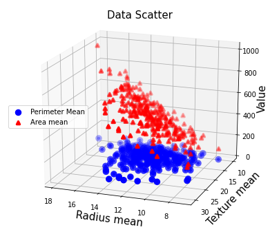

```python
fig = plt.figure(figsize=(7,6))
ax = fig.add_subplot(111, projection='3d')
ax.view_init(20, 110)
ax.scatter(X[:,0], X[:,1], Y[:,0],  color='blue',lw=5)
ax.scatter(X[:,0], X[:,1], Y[:,1], color='red', marker='^', linewidth=3)
plt.legend(('Perimeter Mean','Area mean'), loc='center left')
ax.set_xlabel('Radius mean',fontsize=15)
ax.set_ylabel('Texture mean',fontsize=15)
ax.set_zlabel('Value', fontsize=15)
ax.set_title('Data Scatter', fontsize=15)
plt.show()
```

## Langkah 4 Menentukan model

```python
A = np.insert(X, 0, np.ones(m), 1)
print(A[1:5,:])
print("...")
```

```
[[ 1.     9.504 12.44 ]
 [ 1.     8.196 16.84 ]
 [ 1.    12.05  14.63 ]
 [ 1.    13.64  16.34 ]]
...
```

```python
C = np.linalg.inv(np.transpose(A)@A)@np.transpose(A)@Y
print("Coefficients: ")
print(C)
```

```
Coefficients:
[[-1.64180302e+00 -4.44078384e+02]
 [ 6.58667574e+00  7.49990297e+01]
 [-1.46097985e-02 -2.05221088e-01]]
```

```python
def fPerimeter(x1,x2):
  return C[0][0] + C[1][0]*x1 + C[2][0]*x2

def fArea(x1,x2):
  return C[0][1] + C[1][1]*x1 + C[2][1]*x2
```

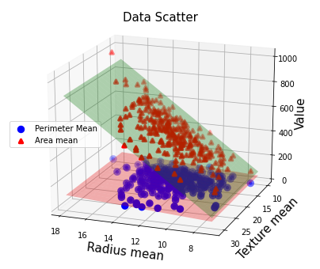

```python
xp = np.linspace(min(X[:,0]),max(X[:,0]),100)
yp = np.linspace(min(X[:,1]),max(X[:,1]),100)

Xp,Yp = np.meshgrid(xp,yp)
Z1 = fPerimeter(Xp,Yp)
Z2 = fArea(Xp,Yp)

fig = plt.figure(figsize=(7,6))
ax = fig.add_subplot(111, projection='3d')
ax.view_init(20, 110)
ax.scatter(X[:,0], X[:,1], Y[:,0],  color='blue',lw=5)
ax.scatter(X[:,0], X[:,1], Y[:,1], color='red', marker='^', linewidth=3)
ax.plot_surface(Xp, Yp, Z1, alpha=0.3, color='red', rstride=6, cstride=12)
ax.plot_surface(Xp, Yp, Z2, alpha=0.3, color='green', rstride=6, cstride=12)
plt.legend(('Perimeter Mean','Area mean'), loc='center left')
ax.set_xlabel('Radius mean',fontsize=15)
ax.set_ylabel('Texture mean',fontsize=15)
ax.set_zlabel('Value', fontsize=15)
ax.set_title('Data Scatter', fontsize=15)
plt.show()
```

## Langkah 5. Mengevaluasi model

Gunakan data testing untuk mengevaluasi model.

```python
X = np.asanyarray(test[['radius_mean', 'texture_mean']])
Y = np.asanyarray(test[['perimeter_mean','area_mean']])
m = len(Y)
print(m)


A = np.insert(X, 0, np.ones(m), 1)
```

```
83
```

```python
Yhat = A@C
```

```python
n = 2
p=2
tabel = ANOVATAB_MVLR(Y,Yhat,n,p,m)
tabel
```

|  | SS | df | MS | Fs | pval |
| --- | --- | --- | --- | --- | --- |
| 0 | 4.984266e+08 | 4 | 1.24607e+08 | 833466 | 1.11022e-16 |
| 1 | 2.392066e+04 | 160 | 149.504 | - | - |
| 2 | 4.938458e+08 | 82 | - | - | - |

```python
MSE = tabel.MS[1]
print('MSE=',MSE)
```

```
MSE= 149.50415392146402
```

```python
SSE = tabel.SS[1]
SST = tabel.SS[2]
R2 = 1 - SSE/SST
print('R-squared = ',R2*100, "%")
```

```
R-squared =  99.99515624788506 %
```

# Latihan

1. Buatlah model regresi liner multivariate menggunakan data **X=(carheight, carweight)** dan **y= (price)** serta analisis hasilnya. Plot juga data dan daerah hampiran.
2. Buatlah model regresi liner berganda menggunakan data **X=(carheight, carweight, boreratio, stroke)** dan **y= (price)** serta analisis hasilnya (MSE & R2). (tidak perlu visualisasi data)

```python
!pip install nbconvert
```